# time series analysis in R

**What does the time index tell us?**

Some data are naturally evenly spaced by time. The time series `discrete_data` shown in the top figure has 20 observations, with one observation appearing at each of the discrete time indices 1 through 20. Discrete time indexing is appropriate for `discrete_data`.

The time series `continuous_series` shown in the bottom figure also has 20 observations, it is following the same periodic pattern as `discrete_data`, but its observations are not evenly spaced. Its first, second, and last observations were observed at times 1.210322, 1.746137, and 20.180524, respectively. Continuous time indexing is natural for `continuous_series`, however, the observations are approximately evenly spaced, with about 1 observation observed per time unit. Let’s investigate using a discrete time indexing for `continuous_series`.

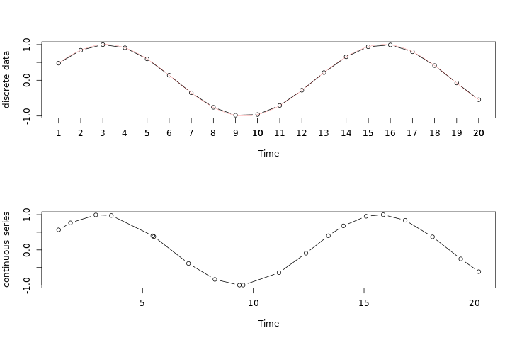

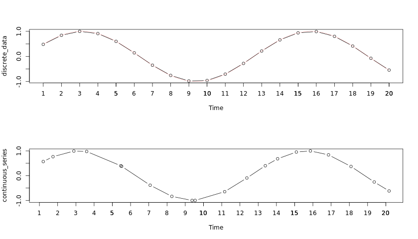

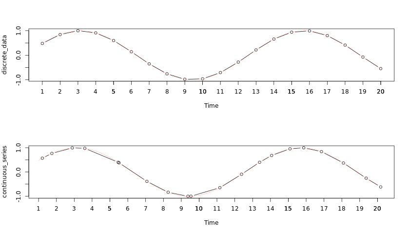

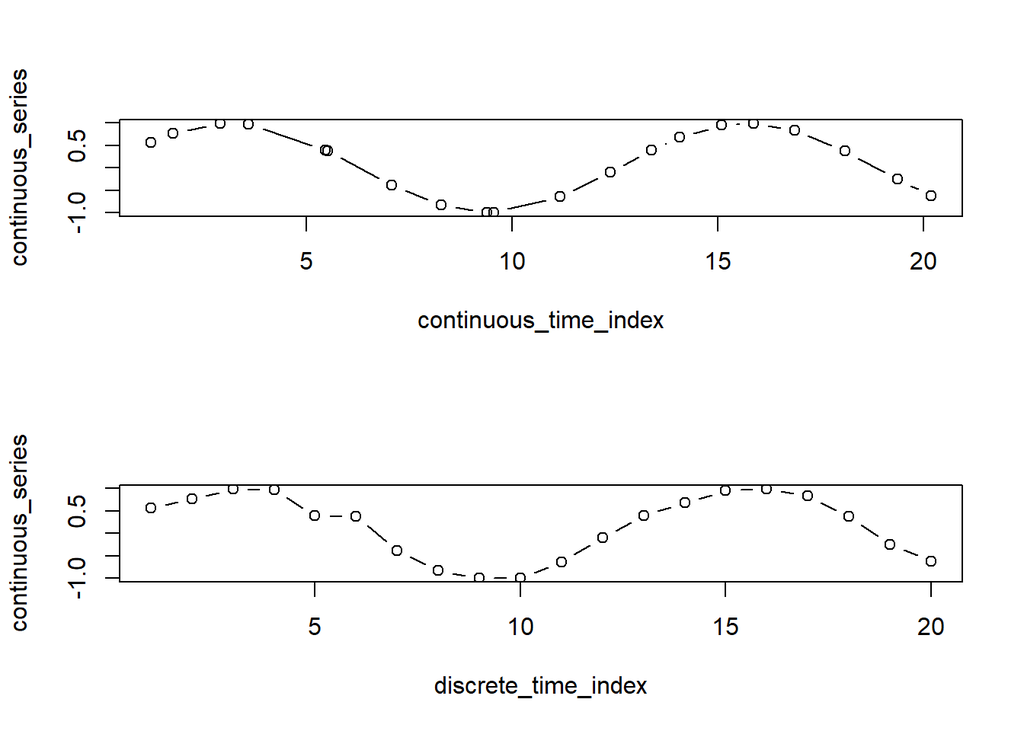

```r
continuous_time_index <- c(1.210322, 1.746137,  2.889634,  3.591384,  5.462065,  5.510933,  7.074295, 8.264398,  9.373382,
                           9.541063, 11.161122, 12.378371, 13.390559, 14.066280, 15.093547, 15.864515, 16.857413, 18.091457,                            19.365451, 20.180524)

continuous_series <- c(0.56889468, 0.76630408, 0.99207512, 0.97481741, 0.39912320, 0.37660246, -0.38532033, -0.83635852,
                       -0.99966983, -0.99831019, -0.64622280, -0.09386151, 0.40052909,  0.68160578,  0.95318159,
                       0.99693803,  0.83934194,  0.37003754, -0.25509676, -0.61743983)

# Plot the continuous_series using continuous time indexing
par(mfrow=c(2,1))
plot(continuous_time_index, continuous_series, type = "b")

# Make a discrete time index using 1:20
discrete_time_index <- 1:20

# Now plot the continuous_series using discrete time indexing
plot(discrete_time_index, continuous_series, type = "b")
```

**Sampling frequency**